# Image Denoising & Filter Dynamics

$Author$: Michael Simons

$Class$: MTH 337 - Mathematical & Scientific Computing

$Date$: 10/5/22

## Introduction

Image noise refers to random variations in the color or brightness of pixels in an image, often arising due to technological constraints such as sensor limitations or environmental factors during capture. A common form of artificially induced noise is "salt and pepper noise," which manifests as random black and white pixels scattered across the image.

This report will explore the generation of noisy images and the application of filtering techniques to reduce noise while maintaining image clarity.

## Generating Noise

To simulate salt and pepper noise, each pixel in an image can be probabilistically altered to either black or white, depending on the noise level. For instance, at a noise level of 0.16, each pixel has an 8% chance of turning white, an 8% chance of turning black, and an 84% chance of remaining unchanged. A random value is generated for each pixel to determine whether and how it will be altered.

```python
import numpy as np

# Apply salt and pepper noise to an image
def sp_noise(img, noise):
    k = img.copy()  # Copy the original image
    for row in k:
        for pixel in row:
            r = np.random.rand()  # Generate a random number
            if r <= (noise / 2):  # Set half of the noise to white pixels
                pixel[:] = 1
            elif r >= (1 - noise / 2):  # Set the other half to black pixels
                pixel[:] = 0
    return k
```

Using this function, noise can be added to an image at varying levels to assess the impact.

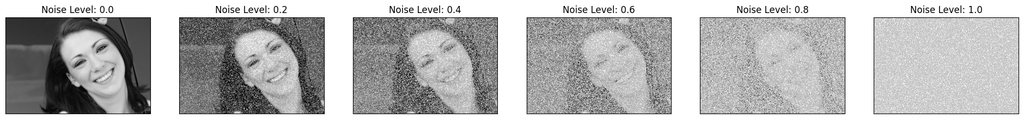

```python
import matplotlib.pyplot as plt
images = [plt.imread(img) for img in ['face.png', 'boston.png', 'circuit.png', 'motorbike.png', 'hamburg.png', 'sign.png']]
plt.figure(figsize=(24, 12))
face = images[0]
for i in [0.0, 0.2, 0.4, 0.6, 0.8, 1.0]:
    plt.subplot(1, 6, int(i * 5) + 1)
    plt.imshow(sp_noise(face, i))
    plt.title(f'Noise Level: {i}')
    plt.xticks([])
    plt.yticks([])
```

## Filtering Images

Noise reduction involves modifying a pixel's value based on its neighbors, typically using filters like mean and median filters. These filters compute either the mean or median of pixel clusters surrounding each pixel. The function `filter_wrapper` will generalize this approach by allowing custom functions to be applied to pixel clusters of any size.

```python
# General filtering function
def filter_wrapper(img, span, function):
    h, w, _ = img.shape
    framed_image = np.zeros((h + 2 * span, w + 2 * span, _))  # Add a frame to handle edge cases
    framed_image[span:h + span, span:w + span] = img.copy()  # Place the image within the frame
    filtered = np.zeros(img.shape)  # Initialize the output image

    for i in range(span, len(framed_image) - span):
        for j in range(span, len(framed_image[i]) - span):
            filtered[i - span, j - span] = function(framed_image[i - span:i + span, j - span:j + span])

    return filtered

# Mean and median filters using the wrapper
def mean_filter(img, span):
    return filter_wrapper(img, span, np.mean)

def median_filter(img, span):
    return filter_wrapper(img, span, np.median)
```

These filters can now be tested on images to observe their behavior with varying filter sizes.

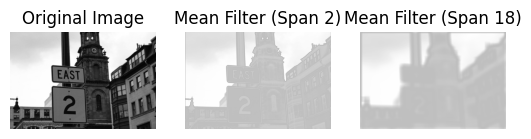

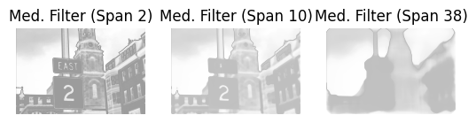

```python
boston = images[1]
plt.subplot(1, 3, 1)
plt.imshow(boston)
plt.title("Original Image")
plt.axis('off')

plt.subplot(1, 3, 2)
plt.imshow(mean_filter(boston, 2))
plt.title("Mean Filter (Span 2)")
plt.axis('off')

plt.subplot(1, 3, 3)
plt.imshow(mean_filter(boston, 18))
plt.title("Mean Filter (Span 18)")
plt.axis('off')
plt.show()

plt.subplot(1, 3, 1)
plt.imshow(median_filter(boston, 5))
plt.title("Mean Filter (Span 5)")
plt.axis('off')

plt.subplot(1, 3, 1)
plt.imshow(median_filter(boston, 2))
plt.title("Med. Filter (Span 2)")
plt.axis('off')

plt.subplot(1, 3, 2)
plt.imshow(median_filter(boston, 10))
plt.title("Med. Filter (Span 10)")
plt.axis('off')

plt.subplot(1, 3, 3)
plt.imshow(median_filter(boston, 38))
plt.title("Med. Filter (Span 38)")
plt.axis('off')
plt.show()
```

## Image Denoising

Now that both filters are functional, we can apply them to noisy images and compare the results. The following example demonstrates their effectiveness on an image with salt and pepper noise.

[figure not shown]

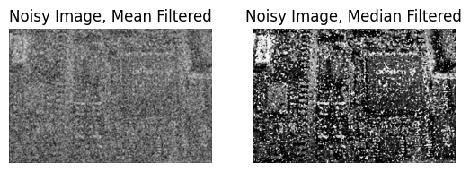

```python
circuit = images[2]
noisy_circuit = sp_noise(circuit, 0.7)
plt.subplot(1, 2, 1)
plt.imshow(circuit)
plt.title('Original Image')
plt.axis('off')

plt.subplot(1, 2, 2)
plt.imshow(noisy_circuit)
plt.title('Noisy Image (Noise Level 0.7)')
plt.axis('off')
plt.show()

# Comparing mean and median filters
plt.subplot(1, 2, 1)
plt.imshow(mean_filter(noisy_circuit, 2))
plt.title('Noisy Image, Mean Filtered')
plt.axis('off')

plt.subplot(1, 2, 2)
plt.imshow(median_filter(noisy_circuit, 2))
plt.title('Noisy Image, Median Filtered')
plt.axis('off')
plt.show()
```

## Designing Other Filters

The flexibility of the filter_wrapper allows for easy experimentation with other filtering techniques, such as standard deviation or variance filters. Additionally, custom filters can be designed to meet specific image processing needs.

```python
def std_filter(img, span):
    return filter_wrapper(img, span, np.std)

def var_filter(img, span):
    return filter_wrapper(img, span, np.var)
```

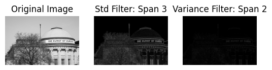

```python
plt.subplot(1, 3, 1)
plt.imshow(images[4])
plt.title('Original Image')
plt.axis('off')

plt.subplot(1, 3, 2)
plt.imshow(std_filter(images[4], 3))
plt.title('Std Filter: Span 3')
plt.axis('off')

plt.subplot(1, 3,3)
plt.imshow(var_filter(images[4], 2))
plt.title('Variance Filter: Span 2')
plt.axis('off')

plt.show()
```